# Challenge_5: Visualizing Time and Space

weekly_challenges

challenge_5

A Halloween Special

Author

Bhavani Priya

Published

October 25, 2023

## Setup

If you have not installed the following packages, please install them before loading them.

```r
library(tidyverse)
library(readr)
library(readxl)
library(haven) #for loading other datafiles (SAS, STATA, SPSS, etc.)

#for plotting time
library(ggplot2) # if you have not installed this package, please install it.
library(lubridate)


#for plotting space
library(sp)
library(sf)
library(maps)
library(rnaturalearth)
library(rnaturalearthdata)

knitr::opts_chunk$set(echo = TRUE, warning=FALSE, message=FALSE)
```

## Challenge Overview

Halloween2023

In this challenge, we will practice the visualization skills learned in the class with two datasets to capture the temporal and spatial patterns of supernatural phenomena.

There will be coding components and writing components. Please read the instructions for each part and complete your challenges.

## Datasets

- Part 1. The UFO Sightings Data (50%)
- Part 2. The Haunted Places Data (50%)

Find the `_data` folder, then read the datasets using the correct R command.

## Part 1. The UFO Sightings Data (50%)

This data contains over 80,000 reports of UFO sightings over the last century in six major countries (and other places). You can learn more about this data by checking: https://www.kaggle.com/datasets/NUFORC/ufo-sightings.

1. **Read and Describe the Data (10%)**

   What is the dimension of the data? What do the columns mean? What is the unit of observation? Dimension of the dataset : 88875 rows, 12 columns The columns give information regarding sightings of ufo, datetime: date on which ufo is spotted, city: in which city did they see it, state and country. Shape gives info about the shape of the ufo, duration: for how many seconds did they spot the ufo, comments: gives info about the ufo, data posted: when did they post the sightings, latitude & longitude of the place. Unit of observation: Information regarding ufo sightings in different places.

```r
   #reading dataset using read_csv
   ufo_data <- read_csv("complete_UFO.csv")
  #sanity check
   head(ufo_data)
```

| datetime | city | state | country | shape | duration (seconds) | duration (hours/min) | comments | date posted | latitude | longitude | ...12 |
| --- | --- | --- | --- | --- | --- | --- | --- | --- | --- | --- | --- |
| 11/11/1906 | wien (austria) | NA | NA | other | 10800 | 3 h | The oldest professional photo of a UFO object is from Wien observatory&#44 in 1906&#33 | 12/23/2002 | 48.208174 | 16.373819 | NA |
| 1/2/1910 | kirksville (near) | mo | us | disk | 120 | minutes | Historical sighting (1903 - 1913) Northern Missouri | 9/15/2005 | 40.1947222 | -92.583056 | NA |
| 5/28/1910 | solon | me | us | unknown | 0 | don&#39t know | entry in my great-grandmother&#39s diary&#44date 28 may 1910&#44refers to watching the comet zig-zaging in the sky&#44 followed by a zig-zag diagra | 12/5/2001 | 44.9494444 | -69.858889 | NA |
| 6/1/1910 | wills point | tx | us | cigar | 120 | 2 minutes | Cigar shaped object moving from West to East | 4/16/2005 | 32.7091667 | -96.008056 | NA |
| 9/15/1914 | meeting lake (canada) | ab | NA | unknown | 0 | NA | Night flying &quot;airplane&quot; with search lights observed on several occasions near Meeting Lake&#44 Alberta in late 1914. | 2/1/2007 | 55.170828 | -118.837956 | NA |
| 4/5/1916 | france (above; from aircraft) | NA | NA | cigar | 60 | about 1 min. | ((NUFORC Note: Possible hoax. PD)) Saw 3 cigar shaped crafts. | 3/9/2004 | 46.227638 | 2.213749 | NA |

```r
   #dimension of the data
   dim(ufo_data)
```

```
[1] 88875    12
```

2. Please plot a temporal/time-series graph to present the following patterns. **You may need to subset or mutate the data for graphing.**

   (1) the total number of UFO sighting reports over the years (date_break = year). **(15%)**

   ```r
   #checking the type of data of datetime column
   typeof(ufo_data$datetime)
   ```

   ```
   [1] "character"
   ```

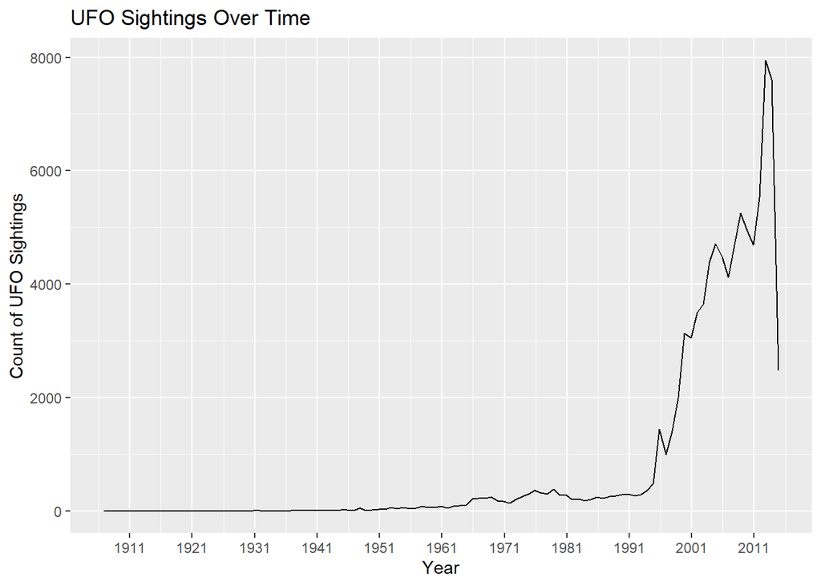

   ```r
   #changing data type to date
   ufo_data$datetime <- as.Date(ufo_data$datetime,'%m/%d/%Y')

   #creating a new dataset with just year_ufo & count column
   ufo_data_year <- ufo_data |>
     mutate(year_ufo = format((datetime),"%Y")) |>
     group_by(year_ufo) |>
     summarise(count_ufo = n())

   #changing data type of year_ufo to date
   ufo_data_year <- ufo_data_year %>%
     mutate(year_ufo = as.Date(year_ufo, '%Y'))

   #creating a line graph with data_breaks
   ufo_data_year |>
     ggplot(aes(x=year_ufo, y=count_ufo)) +
     geom_line() +
     scale_x_date(date_labels = "%Y", date_breaks = "10 years") +
     labs(x = "Year", y = "Count of UFO Sightings", title = "UFO Sightings Over Time")
   ```

   (2) the total number of UFO sighting reports by months between 2010-01-01 and 2014-01-01. **(15%)**

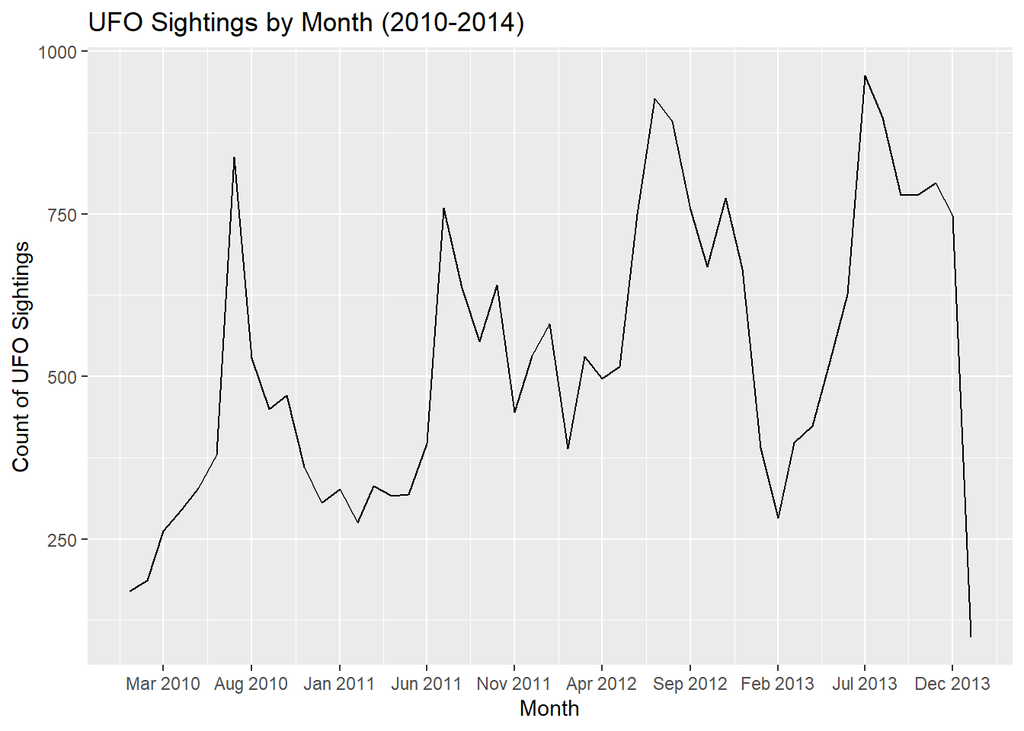

   ```r
   #creating a new dataset with just month_ufo & count_ufo column
   ufo_data_month <- ufo_data |>
     filter(datetime >= '2010-01-10' & datetime<='2014-01-01') |>
     mutate(month_ufo = format(datetime,'%Y-%m')) |>
     group_by(month_ufo) |>
     summarise(count_ufo = n())

      #changing data type of month_ufo to date
      ufo_data_month <- ufo_data_month %>%
     mutate(month_ufo = as.Date(paste0(month_ufo, "-01")))

   #creating a line graph with data_breaks
   ufo_data_month |>
     ggplot(aes(x=month_ufo,y=count_ufo)) +
     geom_line() +
     scale_x_date(date_labels = "%b %Y", date_breaks = "5 months") +
     labs(x = "Month", y = "Count of UFO Sightings", title = "UFO Sightings by Month (2010-2014)")
   ```

3. Please write a paragraph describing the patterns you find on the two graphs above. **(10%)**

UFO Sightings Over Time(by year): - The number of UFO sightings has gone up over the years. - It was almost non-existent between 1908 and 1992. - After 1992, sightings started increasing gradually. - The highest number of sightings was in 2012, with around 8000 reported cases. - Since 2012, the count has been decreasing.

4. **(Optional)** Use `gganimte` and `gifsky` packages to plot gifs of the above time-series plots. You can refer to codes and commands in the Week#8 demo file.

[figure not shown]

   ```r
   #including libraries
   library(gganimate)
   library(gifski)
   library(plotly)
   library(hrbrthemes)

   ufo_data_month$month_ufo <- as.Date(ufo_data_month$month_ufo)

   #animating ufo_by_month
   ufoDataYear_animated <- ggplot(ufo_data_month, aes(x = month_ufo, y = count_ufo)) +
                           geom_line() +
                         labs(x = "Month", y = "Count of UFO Sightings",
                              title = "UFO Sightings by Month (2010-2014)") +
                         scale_x_date(date_labels = "%b %Y", date_breaks = "5 months") +
                         theme_ipsum() +
                         theme(axis.text.x = element_text(angle = 60, hjust = 1))

   ufoDataYear_animated <- ufoDataYear_animated +
     transition_reveal(month_ufo)

   animate(ufoDataYear_animated,
       duration = 5,
       fps = 10,
       width = 500,
       height = 500,
       renderer = gifski_renderer())
   ```

   ```r
   anim_save("UFO_Month.gif")
   ```

5. **(Optional)** Suppose we are interested in describing the country variations in types and numbers of UFO sighting reports. How can we use bar plots to visualize the difference across countries (using the *country* column, you can recode the empty cells with “others”)? **Note that you may need to do the data transformation or mutation needed to help graphing.**

## Part 2. The Haunted Places Data (50%)

This data contains the reports of haunted places in the United States. The dataset was compiled by Tim Renner, using The Shadowlands Haunted Places Index, and shared on data.world. You can learn more about this data by checking: https://www.kaggle.com/datasets/sujaykapadnis/haunted-places

1. **Read and Describe the Data (10%) (Note: you don’t need to remove the empty rows after the first row; `read_csv()` should automatically remove them).**

   What is the dimension of the data? What do the columns mean? What is the unit of observation?

   ```r
   #reading haunted_places csv file
   haunted_places <- read_csv("haunted_places.csv")
   #sanity check
   head(haunted_places)
   ```

   | city | country | description | location | state | state_abbrev | longitude | latitude | city_longitude | city_latitude |
   | --- | --- | --- | --- | --- | --- | --- | --- | --- | --- |
   | Ada | United States | Ada witch - Sometimes you can see a misty blue figure floating within a 3-mile radius of the Ada Cemetery on 2 Mile between Egypt Valley and Honey Creek. The story of her origin is as follows: A man s… | Ada Cemetery | Michigan | MI | -85.50489 | 42.96211 | -85.49548 | 42.96073 |
   | Addison | United States | A little girl was killed suddenly while waiting for a school bus by a speeding car. Since her death things have happened. The day of her funeral she started knocking on doors of the house she was born… | North Adams Rd. | Michigan | MI | -84.38184 | 41.97142 | -84.34717 | 41.98643 |
   | Adrian | United States | If you take Gorman Rd. west towards Sand Creek, you will come to a gravel road leading north. A mile or so up this road you will come to narrow one lane trestle bridge. The road goes under this. Legen… | Ghost Trestle | Michigan | MI | -84.03566 | 41.90454 | -84.03717 | 41.89755 |
   | Adrian | United States | In the 1970's, one room, room 211, in the old section of the dorms exhibited several phenomena. Don't know if this still continues today. The door into the room from the hallway, as well as the door i… | Siena Heights University | Michigan | MI | -84.01757 | 41.90571 | -84.03717 | 41.89755 |
   | Albion | United States | Kappa Delta Sorority - The Kappa Delta Sorority is haunted by an entity simply known as 'P'. It is said she was a sister there who died in a car accident. Current sisters there have reported hearing g… | Albion College | Michigan | MI | -84.74518 | 42.24401 | -84.75303 | 42.24310 |
   | Albion | United States | A mysterious lady in white has been spotted in this cemetery. | Riverside Cemetery | Michigan | MI | -84.75306 | 42.23681 | -84.75303 | 42.24310 |

   ```r
   #dimensions of the data
   dim(haunted_places)
   ```

   ```
   [1] 10992    10
   ```

2. Plot a USA map with states boundaries. There are multiple ways of plotting this map. **(15%)**

   You can use the `geom_polygon()` (which requires a data of spatial coordinates for plotting a polygon), or you can use `geom_sf()` (which requires a shapefile of the US). Please refer to the examples in the Week#8 demo file.

   ```r
   #necessary library
   library(sf)

   #unzips the zip file
   system("unzip States_shapefile-shp.zip")
   ```

   ```
   [1] 127
   ```

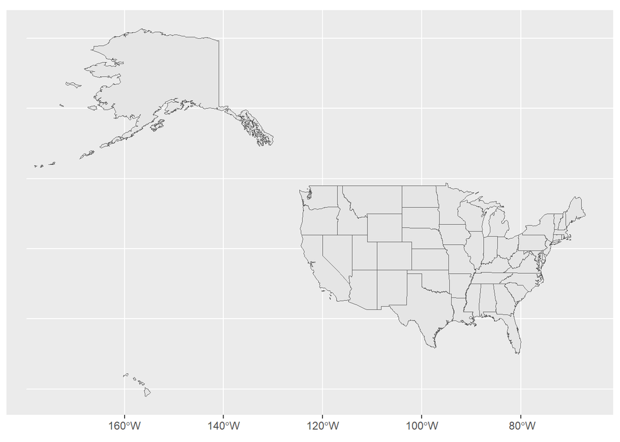

   ```r
   #reads the shp file
   states_sf <- st_read(file.path("./States_shapefile-shp/States_shapefile.shp"))
   #usa map with state boundaries
   states<-ggplot()+
      geom_sf(data = states_sf)

   states
   ```

3. Plot the haunted places using the *city_longtitude* and *city_latitude* with `geom_point()` on the USA map generated above. **(15%)**

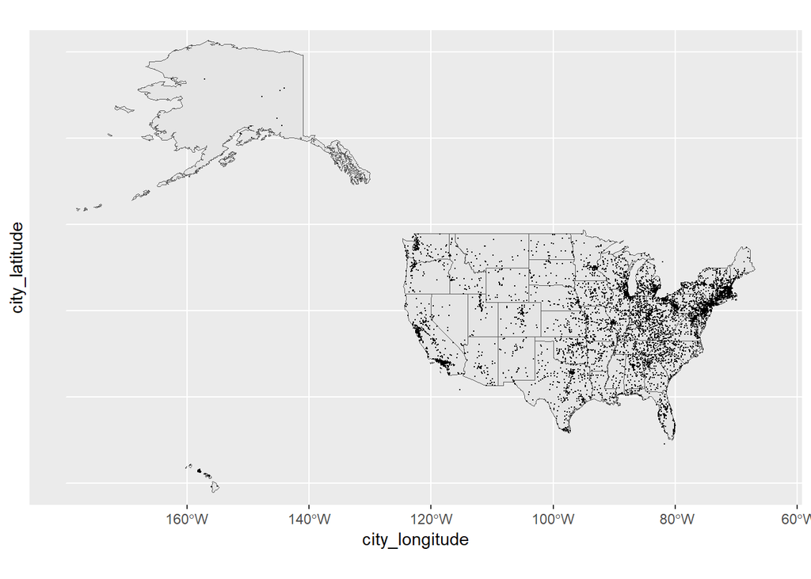

   ```r
   library(maps)

   #grouping haunted_places by state & city
   haunted_places_group <- haunted_places |>
     group_by(state,city)

   #usa map with cities info of haunted places
   cities_map <- states +
     geom_point(data = haunted_places_group, aes(x=city_longitude, y=city_latitude),pch = 19,
                size=0.00005) +
      coord_sf(xlim = c(-180, -65),
               ylim = c(20, 70))


   cities_map
   ```